# ALRA-healthy-analysis

Jacopo Umberto Verga

2023-04-19

# ALRA interactions

I run ALRA using all the healthy samples with NK cells divided in exhausted and resident. The results are:

```r
library(tidyverse)
library(VennDiagram)
library(stringr)
all_interactions <- read_csv("all_healthy_interactions_default.csv", col_types = cols(...1 = col_skip()))

cat("Total number of interactions: ",dim(all_interactions)[1],"\nUnique Ligands: ",length(unique(sort(all_interactions$ligand.complex))),"\nUnique Receptors: ",length(unique(sort(all_interactions$receptor.complex))))
```

```
## Total number of interactions:  15346
## Unique Ligands:  201
## Unique Receptors:  199
```

Focusing on NK cells we have:

```
## Exhausted cells:
## Total number of interactions:  750
## Unique Ligands:  63
## Unique Receptors:  56
```

```
## Resident cells:
## Total number of interactions:  579
## Unique Ligands:  66
## Unique Receptors:  55
```

Less than the BM atlas, due to less interactions or less cells?

## Ligands

Let’s check if the lists of ligands are similar or not:

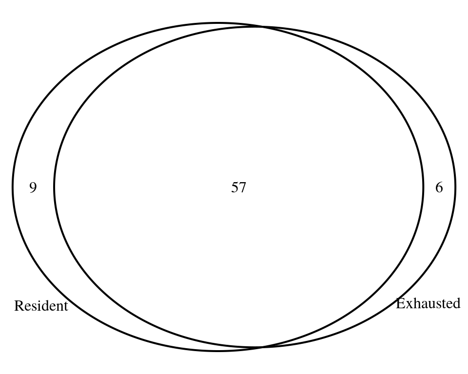

```r
exh_uniq = unique(sort(exh$ligand.complex))
res_uniq = unique(sort(res$ligand.complex))

grid.newpage()
venn_object <- venn.diagram(
        x = list(exh_uniq, res_uniq),
        category.names = c("Exhausted", "Resident"),
        filename = NULL
        )
grid.draw(venn_object)
```

Most of the ligands are shared by the 2 cell types

```r
cat("Unique ligands for NK exhausted:\n", setdiff(exh_uniq,res_uniq), "\nUnique ligands for NK resident:\n", setdiff(res_uniq,exh_uniq))
```

```
## Unique ligands for NK exhausted:
##  F13A1 GZMB HLA-A HLA-C IGF1 ITGB2
## Unique ligands for NK resident:
##  ADAM15 ADAM17 CD58 CLEC11A MIF PKM PTDSS1 SPTAN1 TOR2A
```

### Exhausted:

- F13A1, coagulation factor, from megakaryocyte progenitors to integrins
- [GZMB](https://www.ncbi.nlm.nih.gov/pmc/articles/PMC3627678/) from other NK cells, Plasmacytois dc, CD8+ e.m. T cells, bind IGF2R.
- IGF1 from plasma cells bind IGF2R
- ITGB2 interacts with activating receptorCD226/DNAM-1

### Resident

- ADAM15, binds ITGB1
- ADAM17, binds ITGB1, [it cleavs CD16a in NK cells](https://doi.org/10.1002%2FJLB.2MR1218-501R)
- [CD58](https://www.frontiersin.org/articles/10.3389/fimmu.2020.01090/full) stimulator for CD2
- CLEC11A, binds ITGB1, [Promotes osteogenesis by stimulating the differentiation of mesenchymal progenitors into mature osteoblasts](https://www.genecards.org/cgi-bin/carddisp.pl?gene=CLEC11A)
- MIF, inflammatory cytokine binds:
  - [CD44/CD74/CXCR4](https://doi.org/10.3389/fimmu.2020.609948): inhibits NK citotoxycity
  - TNFRSF14, in Chellphone DB 2.#, not in v.4 hard to find references
- SPTAN1 interact with [NCAM(CD56)/FYN complex](http://www.reactome.org/content/detail/REACT_18389.3)

## Receptors

Let’s check if the lists of receptors are similar or not:

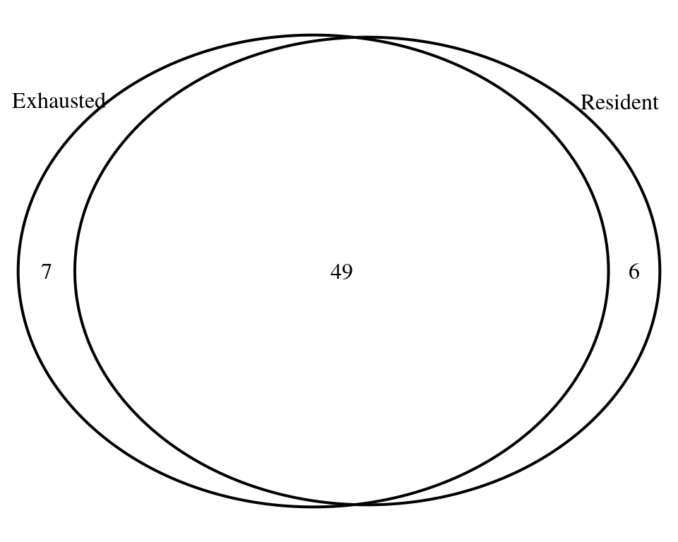

```r
exh_rec = unique(sort(exh$receptor.complex))
res_rec = unique(sort(res$receptor.complex))

grid.newpage()
venn_object <- venn.diagram(
        x = list(exh_rec, res_rec),
        category.names = c("Exhausted", "Resident"),
        filename = NULL
        )
grid.draw(venn_object)
```

Most of the receptors are shared by the 2 cell types

```r
cat("Unique receptors for NK exhausted:\n", setdiff(exh_rec,res_rec), "\nUnique receptors for NK resident:\n", setdiff(res_rec,exh_rec))
```

```
## Unique receptors for NK exhausted:
##  CD226 CD74 HAVCR2 IGF2R KIR2DL3 KLRC2 KLRC2_KLRD1
## Unique receptors for NK resident:
##  APLP2 ATP5F1B CD44_CD74 CD74_CXCR4 JMJD6 LAMP1
```

### Exhausted

- CD226 Activating receptor
- HAVCR2/TIM3, activated by numerous cell types, by:
  - [HMGB1](https://doi.org/10.1038/ni.2396) inhibits antitumor efficancy
  - LGALS9/Galectin-9
- IGF2R, ligand GZMB, from NK cells, Plasmacytoid dc, CD8+ em T cells, Plasma cells
- KIR2DL3, inhibitory KIR
- KLRC2, activating KIR
- KLRC2_KLRD1, [activating receptor](https://www.uniprot.org/uniprotkb/O54707/entry)

## Number of interacting cells

Evaluate the proportion of celltypes that interacts with our NK cells:

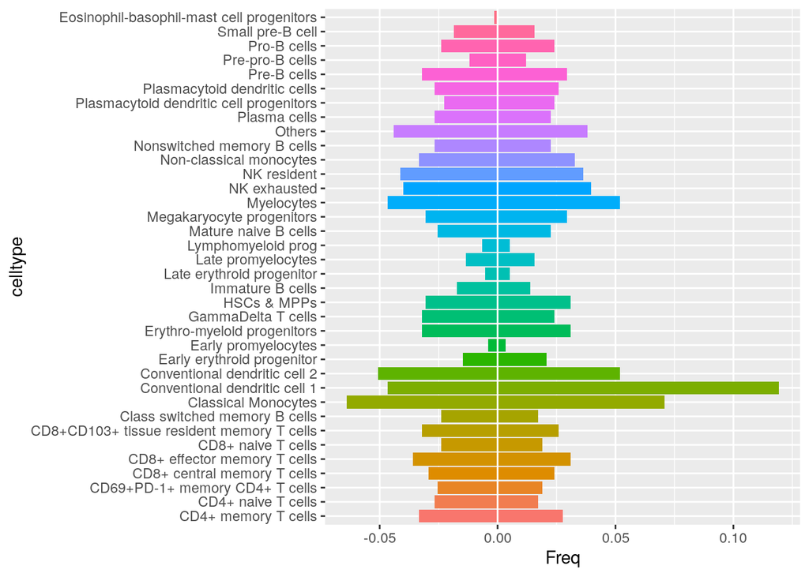

```r
exh_source <- as.data.frame(table(exh$source)/sum(table(exh$source))) %>%
  rename(celltype = "Var1") %>%
  mutate(condition="exh")
res_source <- as.data.frame(table(res$source)/sum(table(res$source))) %>%
  rename(celltype = "Var1") %>%
  mutate(condition="res")

source <- rbind(res_source,exh_source)

source_plot <- source %>%
  mutate(
    Freq = ifelse(condition=="exh", Freq*(-1),
                        Freq*1))%>%
    ggplot(aes(x = celltype,y = Freq, fill=celltype)) +
    geom_bar(stat = "identity") +
    coord_flip() +
  geom_hline(yintercept = 0, color="white")+
  theme(legend.position = "none")

source_plot
```

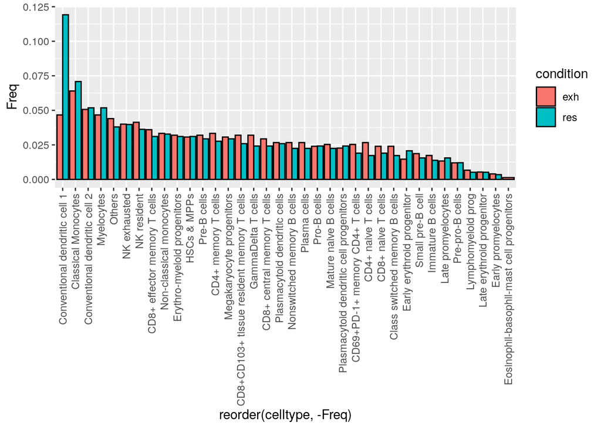

```r
source_dodge <- ggplot(source, aes(x=reorder(celltype,-Freq), y=Freq, fill=condition)) +
geom_bar(stat="identity", color="black", position=position_dodge())+
  theme(axis.text.x = element_text(angle = 90, vjust = 0.5, hjust=1))

source_dodge
```

Resident cells present more interactions with Conventional dendritic cells compared to exhausted cells

Now let’s check the receptors that receive most interaction from other cell types (top 10 for each NK cell for the sake of readability)

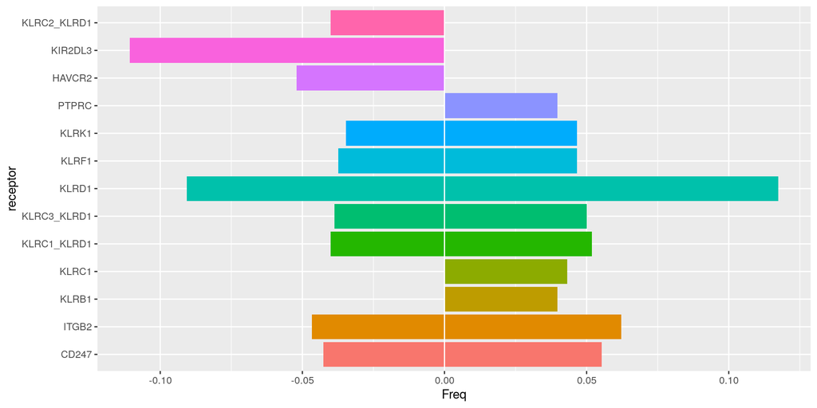

```r
exh_source <- as.data.frame(table(exh$receptor.complex)/sum(table(exh$receptor.complex))) %>%
  arrange(desc(Freq)) %>%
  rename(receptor = "Var1") %>%
  mutate(condition="exh")
res_source <- as.data.frame(table(res$receptor.complex)/sum(table(res$receptor.complex))) %>%
  arrange(desc(Freq)) %>%
  rename(receptor = "Var1") %>%
  mutate(condition="res")

source <- rbind(res_source[1:10,],exh_source[1:10,])

source_plot <- source %>%
  mutate(
    Freq = ifelse(condition=="exh", Freq*(-1),
                        Freq*1))%>%
    ggplot(aes(x = receptor,y = Freq, fill=receptor)) +
    geom_bar(stat = "identity") +
    coord_flip() +
    geom_hline(yintercept = 0, color="white")+

  theme(legend.position = "none")

source_plot
```

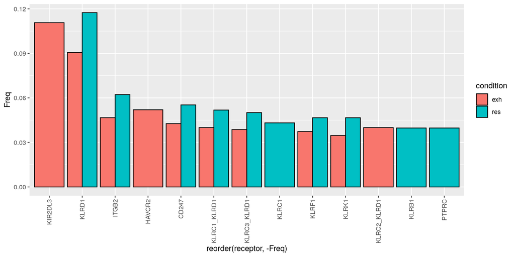

```r
source_dodge <- ggplot(source, aes(x=reorder(receptor,-Freq), y=Freq, fill=condition)) +
geom_bar(stat="identity", color="black", position=position_dodge())+
  theme(axis.text.x = element_text(angle = 90, vjust = 0.5, hjust=1))

source_dodge
```

- KLRC2_KLRD1, [activating receptor](https://www.uniprot.org/uniprotkb/O54707/entry)
- KIR2DL3, inhibitory KIR
- HAVCR2/TIM3
- KLRK1/KLRF1 activating KIR
- KLRC1/KLRD1, INHIBITORY RECEPTOR
- KLRC3/KLRD1
- KLRB1, inhibitory receptor
- CD247, activating receptor

## Immune checkpoint receptors:

Now have a look on the immune checkpoint receptors in exhausted cells:

```r
ICR = c("KLRB1|KLRC1|KLRD1|KIR2DL1|KIR2DL3|KIR3DL1|KIR3DL2|KLRG1|KIR2DL4|TIGIT|LAG3|HAVCR2|BTLA|PDCD1|LILRB1|LILRB2|LILRB3|LILRB4|LILRB5|SIGLEC7|LAIR1|CEACAM1|PILRA|CD300A|CD96")

exh_ICR <- exh %>%
  filter(grepl(ICR,receptor.complex)) %>%
  filter(!grepl("KLRC2|KLRC3", receptor.complex))

res_ICR <- res %>%
  filter(grepl(ICR,receptor.complex)) %>%
  filter(!grepl("KLRC2|KLRC3", receptor.complex))


cat("Exhausted cells:\nTotal number of ICR interactions: ",dim(exh_ICR)[1],"\nUnique Ligands: ",length(unique(sort(exh_ICR$ligand.complex))),"\nUnique Receptors: ",length(unique(sort(exh_ICR$receptor.complex))),"\n\n")
```

```
## Exhausted cells:
## Total number of ICR interactions:  268
## Unique Ligands:  11
## Unique Receptors:  7
```

```r
cat("Resident cells:\nTotal number of interactions: ",dim(res_ICR)[1],"\nUnique Ligands: ",length(unique(sort(res_ICR$ligand.complex))),"\nUnique Receptors: ",length(unique(sort(res_ICR$receptor.complex))))
```

```
## Resident cells:
## Total number of interactions:  149
## Unique Ligands:  6
## Unique Receptors:  5
```

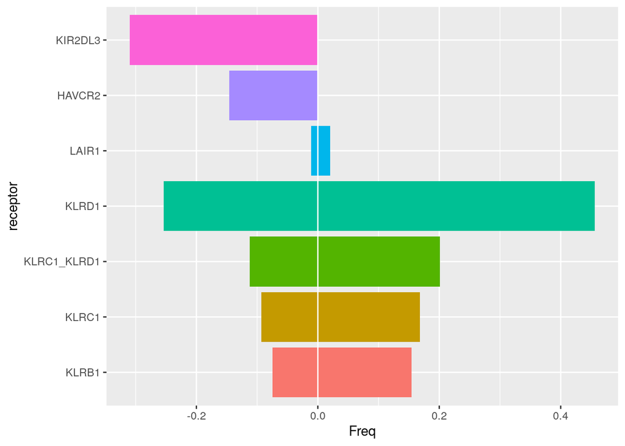

```r
exh_source <- as.data.frame(table(exh_ICR$receptor.complex)/sum(table(exh_ICR$receptor.complex))) %>%
  arrange(desc(Freq)) %>%
  rename(receptor = "Var1") %>%
  mutate(condition="exh")
res_source <- as.data.frame(table(res_ICR$receptor.complex)/sum(table(res_ICR$receptor.complex))) %>%
  arrange(desc(Freq)) %>%
  rename(receptor = "Var1") %>%
  mutate(condition="res")

source <- rbind(res_source,exh_source)

source_plot <- source %>%
  mutate(
    Freq = ifelse(condition=="exh", Freq*(-1),
                        Freq*1))%>%
    ggplot(aes(x = receptor,y = Freq, fill=receptor)) +
    geom_bar(stat = "identity") +
    coord_flip() +
    geom_hline(yintercept = 0, color="white")+

  theme(legend.position = "none")

source_plot
```

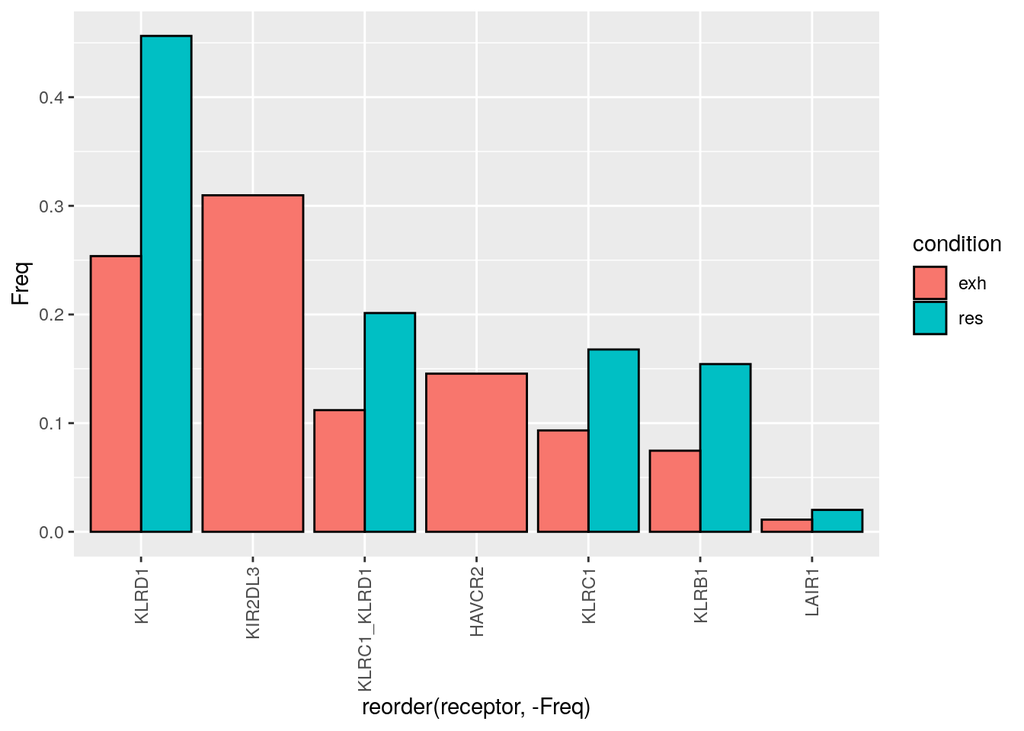

```r
source_dodge <- ggplot(source, aes(x=reorder(receptor,-Freq), y=Freq, fill=condition)) +
geom_bar(stat="identity", color="black", position=position_dodge())+
  theme(axis.text.x = element_text(angle = 90, vjust = 0.5, hjust=1))

source_dodge
```

# Conclusions

- Results show different receptors activated in exhausted and resident cell
- less inhibitory receptors in the highly activated receptors
- less immune checkpoints
- lack of TIM3, and KIR2D3L in resident nk cells